# Affymetrix-Analyses in Qing et al. 2022, npj Breast Cancer, PMID: 36344517

### Violin plots comparing signatures in young vs old (Figure 1, Cohort-B)

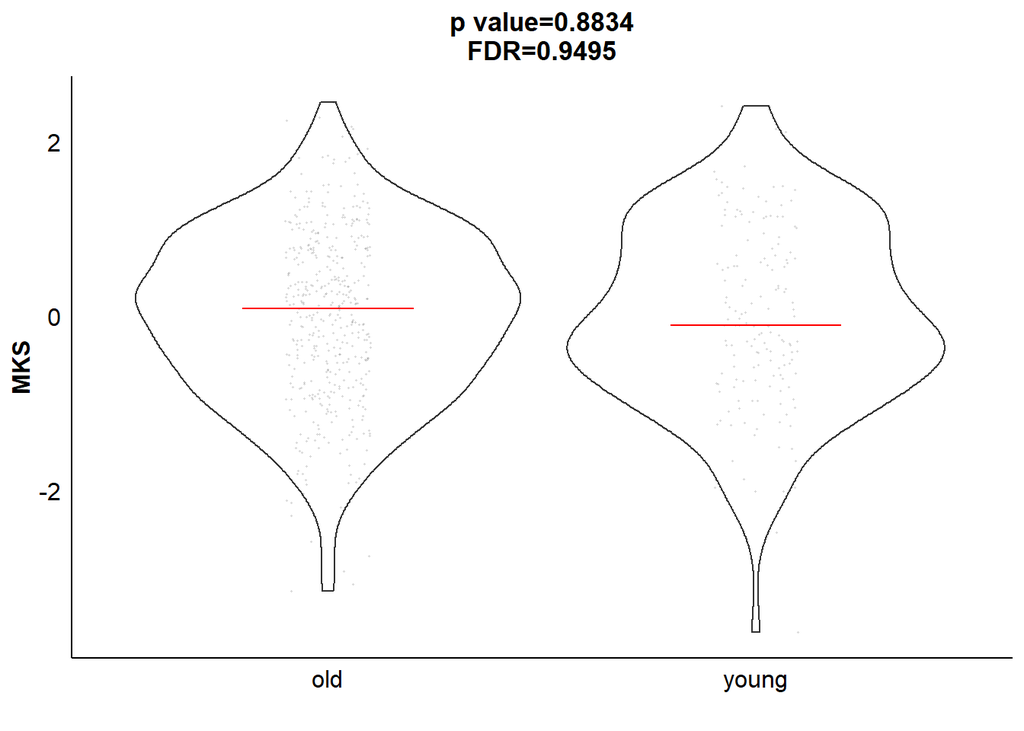

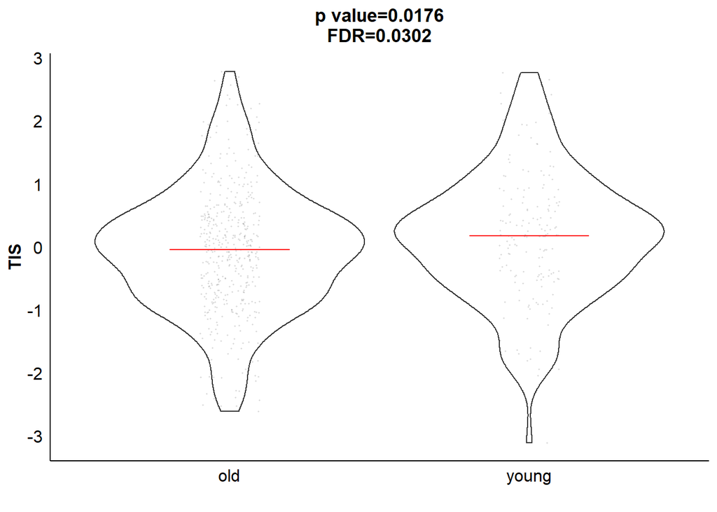

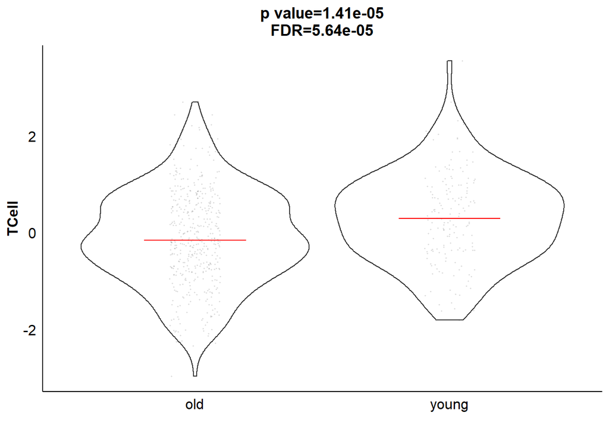

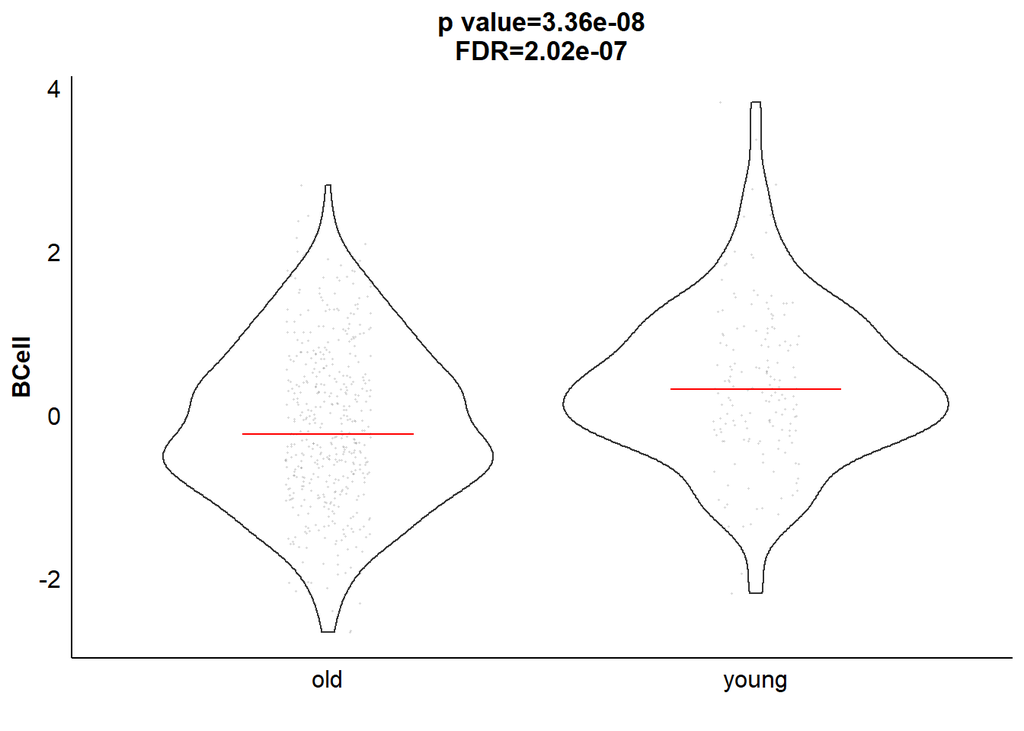

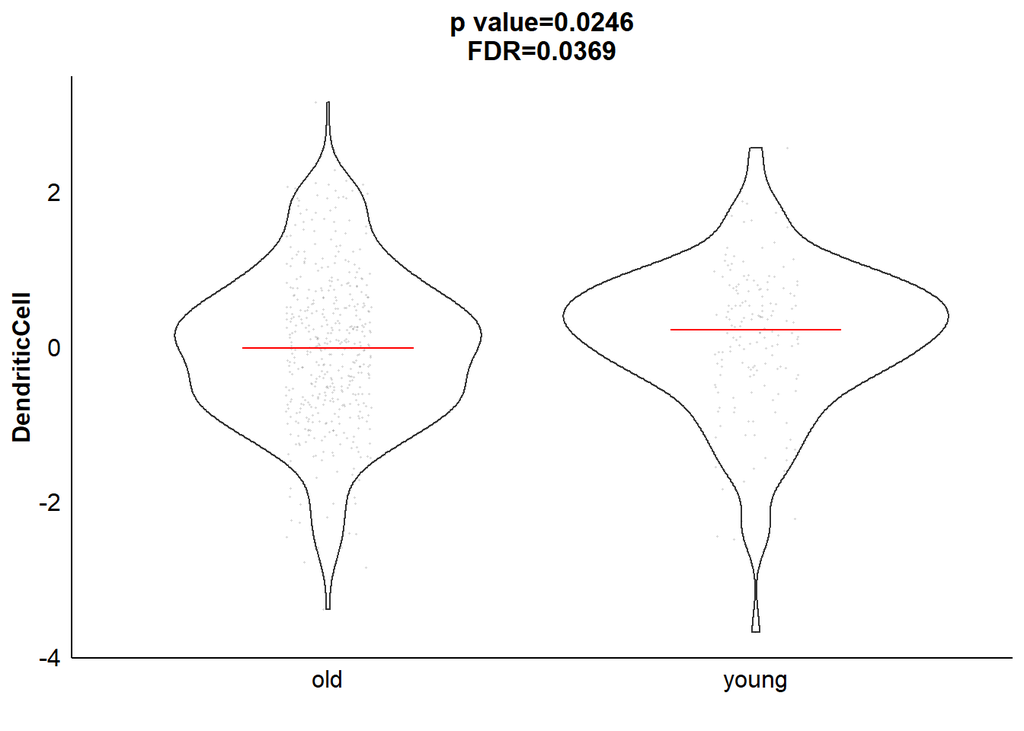

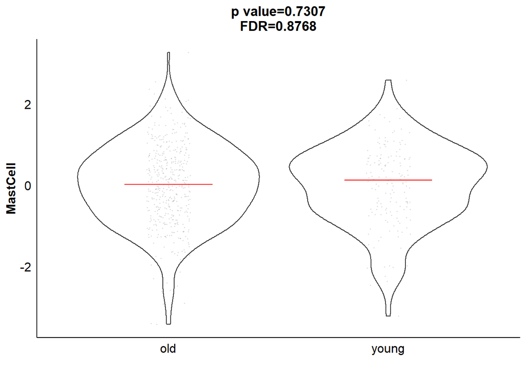

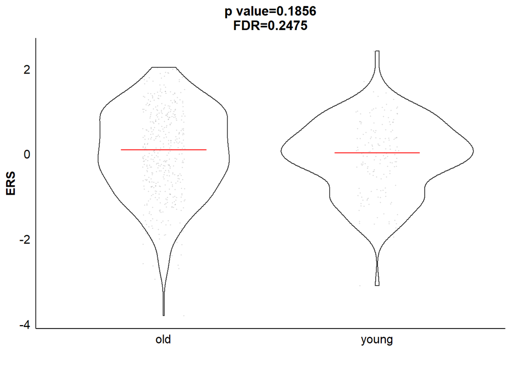

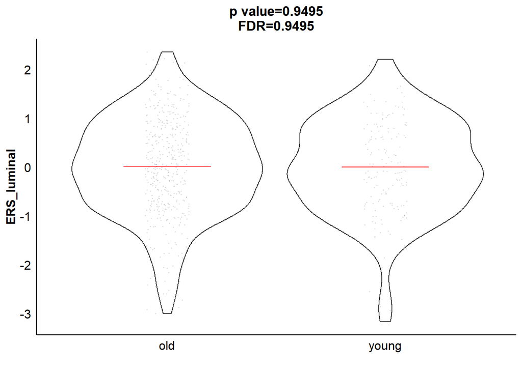

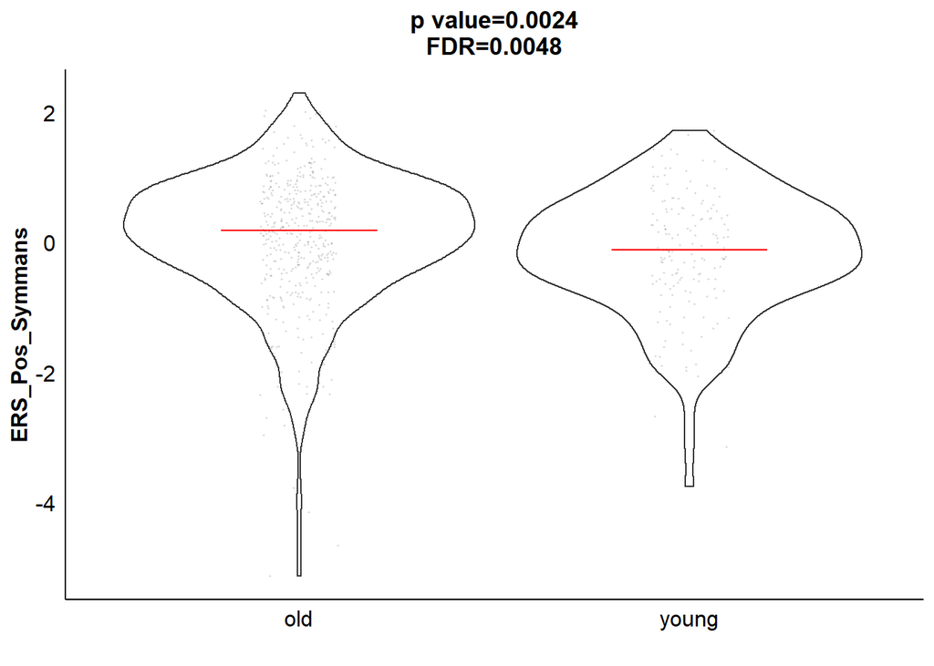

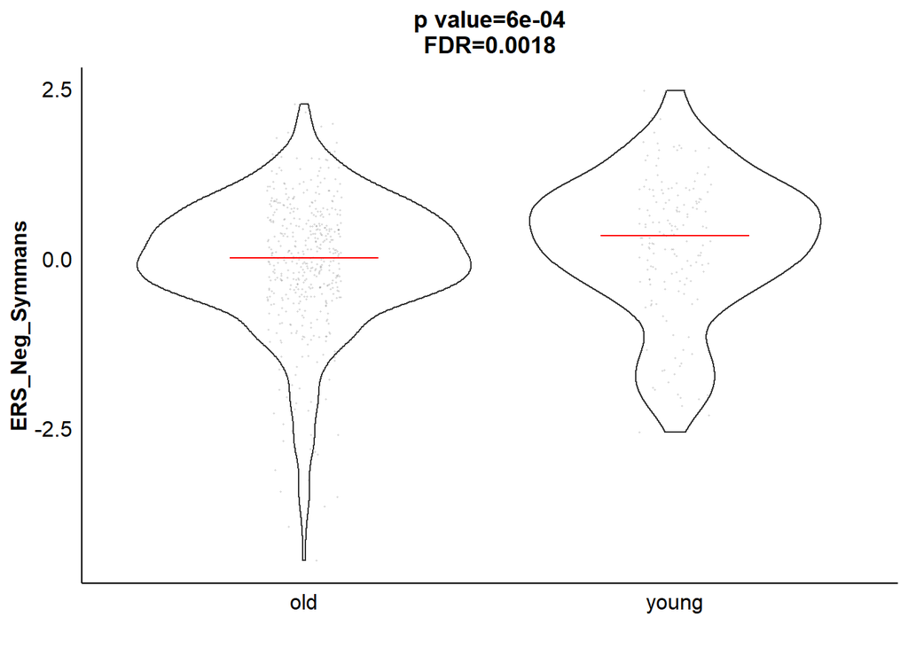

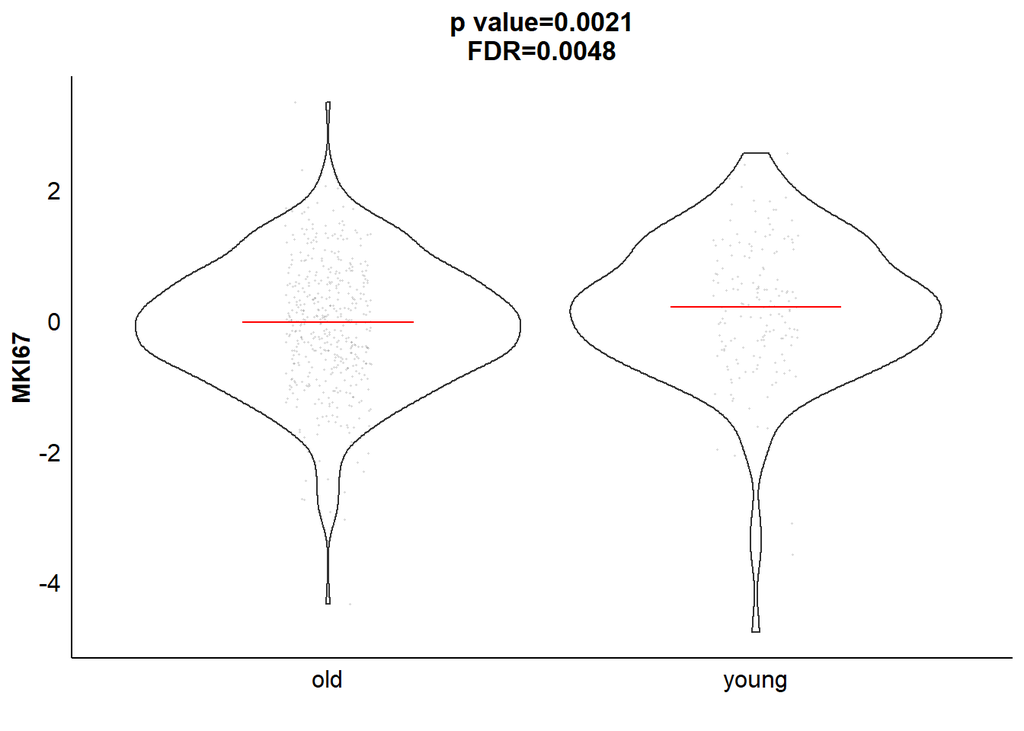

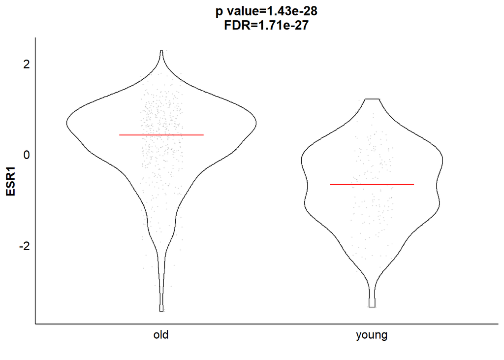

```r
for(s in rownames(mat_signature)){
  submat=finalMat[,c("type",s)]
  colnames(submat)[2]="Signature"
  med <- submat %>%
    group_by(type) %>%
    filter(!is.na(type)) %>%
    summarize(med = median(as.numeric(as.matrix(Signature))))

  if(ttMW$Pvalue[ttMW$Signature==s]<0.0001){
    pvalue<-formatC(ttMW$Pvalue[ttMW$Signature==s], format = "e", digits = 2)
  }else{
    pvalue=round(ttMW$Pvalue[ttMW$Signature==s],digits=4)
  }

  if(ttMW$FDR[ttMW$Signature==s]<0.0001){
    FDR<-formatC(ttMW$FDR[ttMW$Signature==s], format = "e", digits = 2)
  }else{
    FDR=round(ttMW$FDR[ttMW$Signature==s],digits=4)
  }

  p=ggplot(submat,
           aes(x=type,y=as.numeric(as.matrix(Signature)))) +
    geom_violin() +
    geom_jitter(alpha=.1,width = .1,size=.2)+th+ggtitle(paste0("p value=",pvalue,"\nFDR=",FDR))+xlab("")+ylab(s)+
    geom_segment(data = med,
                 aes(y=med,yend=med,x=as.numeric(type)-.2,
                     xend=as.numeric(type)+.2),color="red")
plot(p)
}
```

## COHORT-B Limma analysis for identifying differentially expressed genes (Fig.2c, Supp.Tab.S3)

Load required packages:

```r
library(limma)
# The following block is for Affy probeset annotations
options(connectionObserver = NULL) # temporary solution of  bug in the communication between the latest release of the RSQLite package and RStudio
library(hgu133a.db)
library(annotate)
```

Perform limma analysis for young vs old with Affymetrix source dataset as batch covariate:

```r
type <- clin$type
batch <- factor(clin$datas_new09...TransBIG.40.)
# Construct model matrix including both  batch and type
X <- model.matrix(~batch+type)
# Use limma to fit gene expression in mat to model matrix
fit <- lmFit(mat,X)
# Add Gene Symbols
fit$genes$probeset <- row.names(fit)
fit$genes$Symbol <- getSYMBOL(fit$genes$probeset,"hgu133a.db")
# Empirical Bayes Statistics for Differential Expression
fit <- eBayes(fit)
results <- decideTests(fit)
summary(results)
```

```
##        (Intercept) batch14 batch23 batch29 batch31 batch37 batch42 batch44
## Down             0   12746   11666   20659   11309   17261    8296    9575
## NotSig           0    4286    5265    1396    5878    5014    5192    8271
## Up           22283    5245    5346     213    5096       2    8789    4431
##        batch47 batch50 batch52 batch53 batch60 batch62 typeyoung
## Down      8507    5902   10459     191    7794    9734       312
## NotSig    8374   10820    6091   22078   12307    7047     21234
## Up        5388    5555    5727       8    2176    5496       737
```

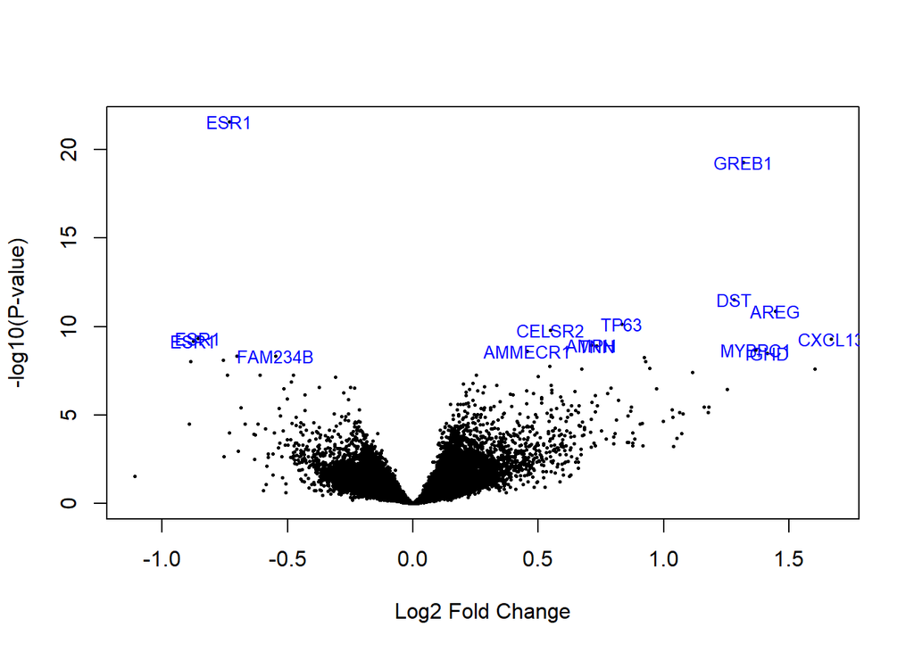

```r
volcanoplot(fit, coef="typeyoung", highlight = 15, names=fit$genes$Symbol)
```

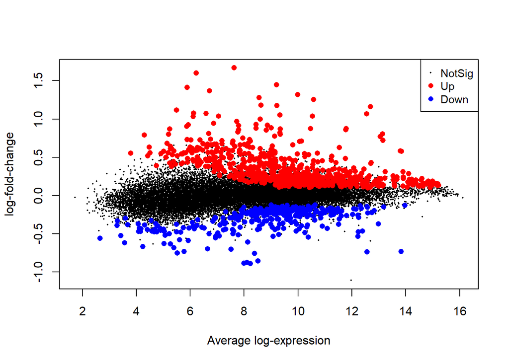

```r
plotMD(fit, coef="typeyoung", status=results)
```

```r
nSigGenes <- summary(results)[1,15]  + summary(results)[3,15]
deg.cohortB <- topTable(fit, coef = "typeyoung", n=nSigGenes)
# filter   FC ≥ 1.50 or ≤0.67
deg.cohortB.fil <- deg.cohortB[ (2^(deg.cohortB$logFC)>=1.5) | (2^(deg.cohortB$logFC)<=1/1.5) ,]
deg.cohortB.fil
```

|  | ID.probeset | ID.Symbol | logFC | AveExpr | t | P.Value | adj.P.Val | B |
| --- | --- | --- | --- | --- | --- | --- | --- | --- |
| 205225_at | 205225_at | ESR1 | -0.7320678 | 13.821460 | -10.107081 | 2.815458e-22 | 6.273685e-18 | 38.713268350 |
| 205862_at | 205862_at | GREB1 | 1.3196473 | 9.995983 | 9.494455 | 5.231170e-20 | 5.828308e-16 | 33.812879492 |
| 204455_at | 204455_at | DST | 1.2800652 | 8.561356 | 7.129433 | 2.920180e-12 | 2.169012e-08 | 17.114418167 |
| 205239_at | 205239_at | AREG | 1.4461285 | 9.195527 | 6.900482 | 1.325579e-11 | 7.384470e-08 | 15.703353359 |
| 209863_s_at | 209863_s_at | TP63 | 0.8320507 | 7.770830 | 6.635910 | 7.240889e-11 | 3.226975e-07 | 14.121374278 |
| 215552_s_at | 215552_s_at | ESR1 | -0.8584153 | 8.509831 | -6.327715 | 4.883748e-10 | 1.434758e-06 | 12.345558103 |
| 205242_at | 205242_at | CXCL13 | 1.6683802 | 7.633357 | 6.318934 | 5.151042e-10 | 1.434758e-06 | 12.296028485 |
| 211234_x_at | 211234_x_at | ESR1 | -0.8754661 | 8.101530 | -6.270100 | 6.919866e-10 | 1.713282e-06 | 12.021689881 |
| 205257_s_at | 205257_s_at | AMPH | 0.7102310 | 8.238857 | 6.189213 | 1.123635e-09 | 2.503797e-06 | 11.571368088 |
| 215271_at | 215271_at | TNN | 0.7313824 | 8.207790 | 6.168034 | 1.274596e-09 | 2.581985e-06 | 11.454301637 |

[output cut: 110 more lines]

## Heatmap of differentially expressed genes in younger versus older cases (Suppl.Fig.5, Cohort-B)

Import list of differentially expressed genes common between TCGA-cohort, Affy-Cohort-A, and Affy-Cohort-B.

```r
comm39.genes <- read.delim(paste0(datapath,"Common39Genes-probesets.txt"),h=T)
comm39.genes <- comm39.genes[order(comm39.genes$probeset),] # order by probeset
comm.genes.up <- comm39.genes[comm39.genes$Young=="Up",]
comm.genes.down <- comm39.genes[comm39.genes$Young=="Down",]
```

Combine a plot-matrix with genes in rows and samples in columns:

```r
plotMat <- mat[rownames(mat) %in% comm39.genes$probeset,]
stopifnot(rownames(plotMat)==comm39.genes$probeset)
rownames(plotMat) <- comm39.genes$Gene # add gene names to matrix

type <- clin$type  #type is a character array of age group
plotMat <- plotMat[,order(clin$age)] # reorder columns by patients age
type <- type[order(clin$age)]  # reorder columns by patients age

# scale each gene
plotMat <- t(scale(t(plotMat)))
```

Plot matrix as heatmap:

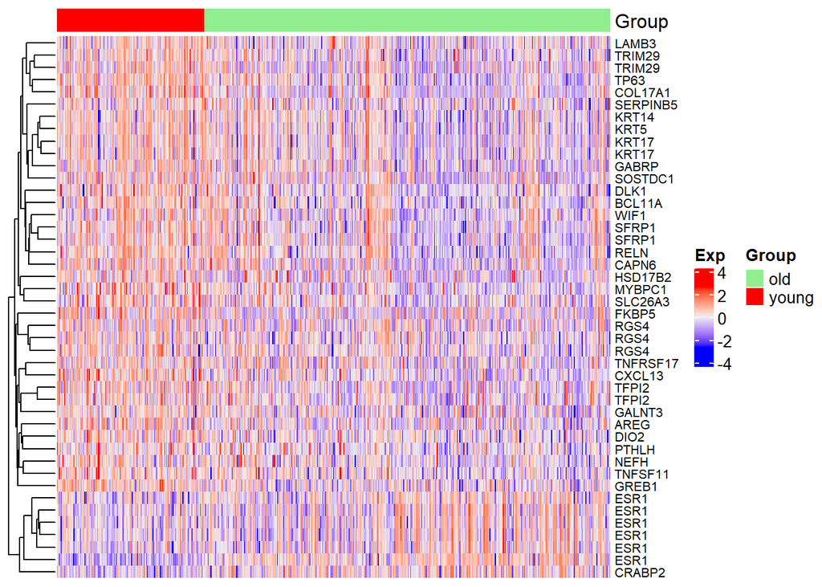

```r
require("ComplexHeatmap")
comm.heatmap=Heatmap(as.matrix(plotMat),name = "Exp",
                  top_annotation = HeatmapAnnotation(Group=type,col=list(Group=c("old"="lightgreen","young"="red"))),
                  show_row_names=TRUE,
                  row_names_gp = gpar(fontsize = 8),
                  show_column_names = FALSE,
                  cluster_columns = FALSE
)
plot(comm.heatmap)
```